# Labb 1

Anton Holm & Simon Melamed

2020-02-07

##Assignment 1

We decided to take a closer look at the Apple and Microsoft share since they are both well established companies working in the same branch. They are also each others rivals which could make for some interesting analysis. Figure 1.1 shows the daily closing price of the Apple share.

```r
Apple <- read_csv('AAPL.csv') %>%
  mutate(logreturn = log(Close/Open))
Microsoft <- read_csv('MSFT.csv') %>%
  mutate(logreturn = log(Close/Open))
```

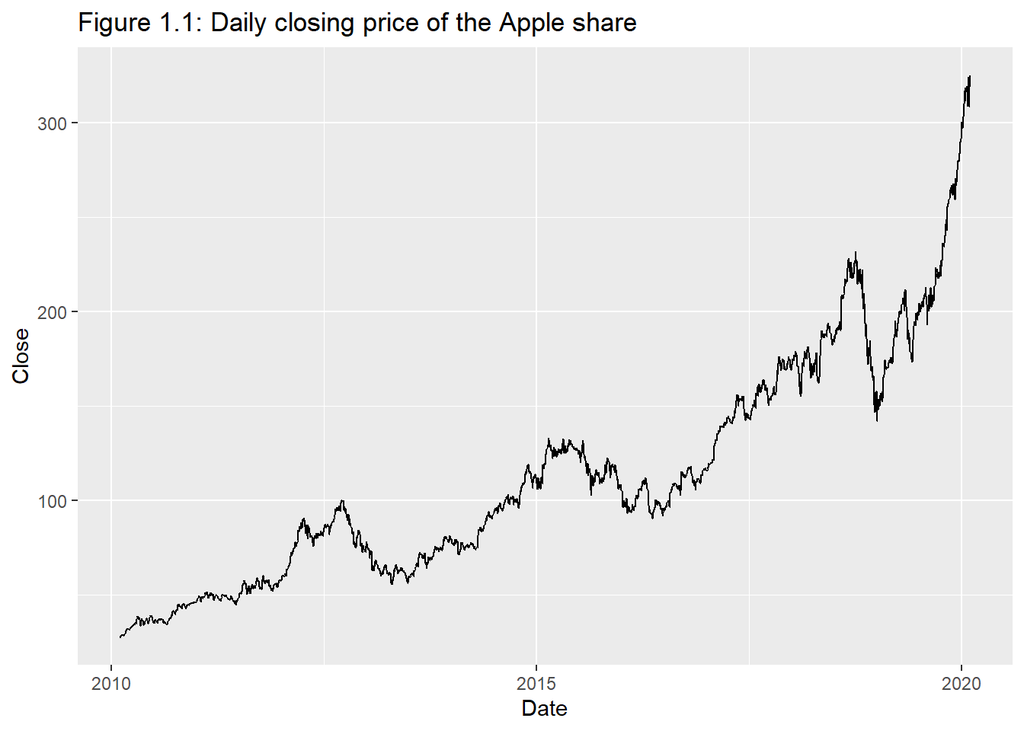

```r
Apple %>%
  ggplot(aes(x=Date, y=Close)) +
  geom_line() +
  labs(title='Figure 1.1: Daily closing price of the Apple share')
```

##Assignment 2

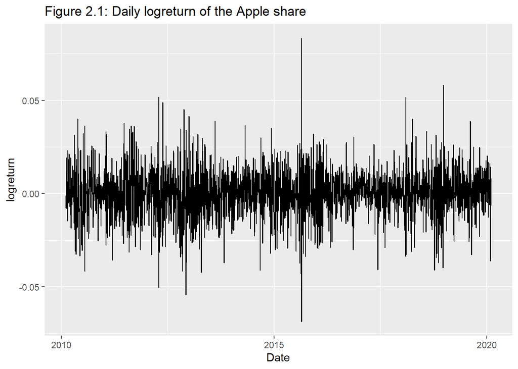

```r
Apple %>%
  ggplot(aes(x=Date, y=logreturn)) +
  geom_line() +
  labs(title='Figure 2.1: Daily logreturn of the Apple share')
```

```r
Delayed_Apple <- Apple[-1,]
No_last_row_Apple <- Apple[-(nrow(Apple)),]


#Autokorrelationen
auto_korr <- cor(Delayed_Apple$logreturn, No_last_row_Apple$logreturn)
```

We also calculated the autocorrelation of the Apple stock which we found to be -0.0923446. This is quite the small correlation considering we can only get a value between $-1$ and $1$, but seeing as the value is negative, we should restrict ourselves from following trends. In other words, the negative auto-correlation implies that if the log-return of the stock is negative one day, it’s more likely to be positve the following day. Hence, we would want to buy shares from a stock that had a negative log-return last day, and not jump on the bandwagon of a stock that went up the day before.

##Uppgift 3

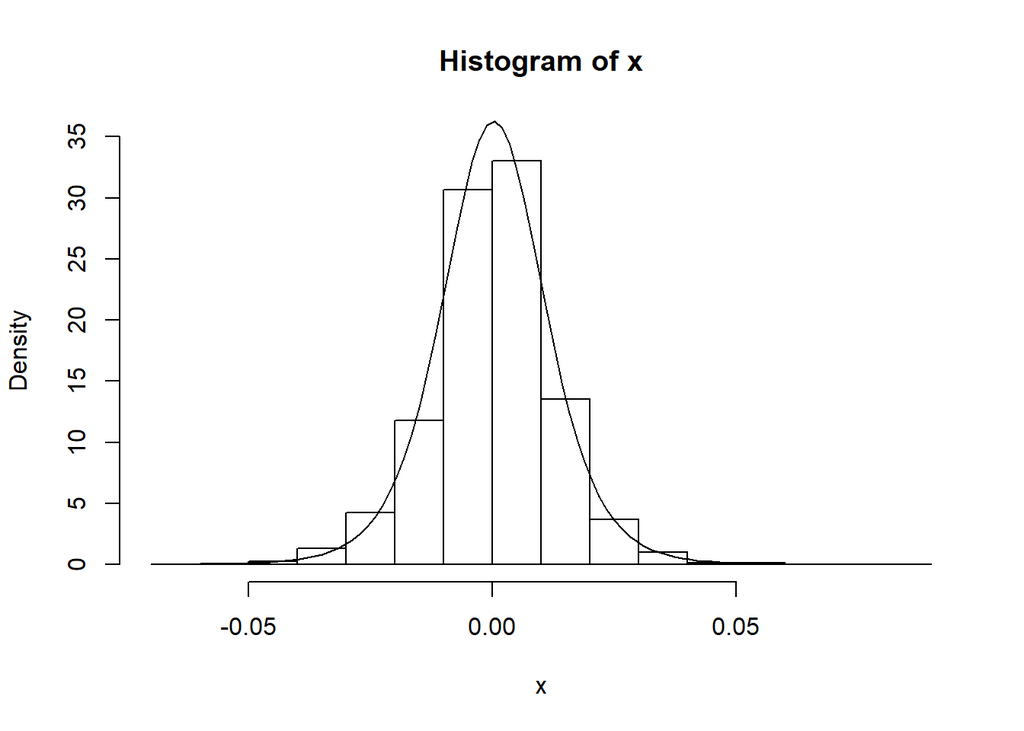

```r
df <- 7
x <- Apple$logreturn

param <- fitdistr(x, "t", df=df, start = list(m=mean(x),s=sd(x)), lower=c(-1, 0.001,1))

mean=param[[1]][1]
sp=param[[1]][2]

hist(x,prob=TRUE,ylim=c(0,35))

x_axis = seq(min(x),max(x),length.out=100)

lines(x_axis,(1/sp)*dt((x_axis-mean)/sp,df))
```

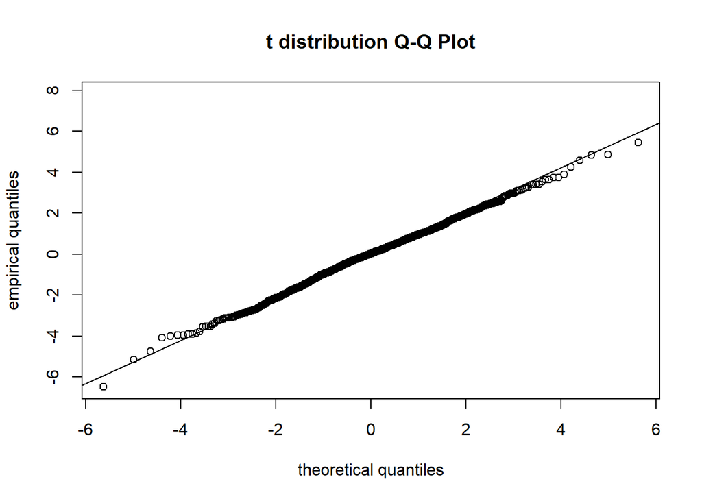

```r
x_normalized = (x-mean)/sp

x_normalized_quantiles = sort(x_normalized)

p = (1:length(x_normalized))/length(x_normalized)
theoretical_quantiles = qt(p,df)




plot(theoretical_quantiles, x_normalized_quantiles, xlab="theoretical quantiles",
     ylab= "empirical quantiles",main="t distribution Q-Q Plot"); qqline(theoretical_quantiles)
```

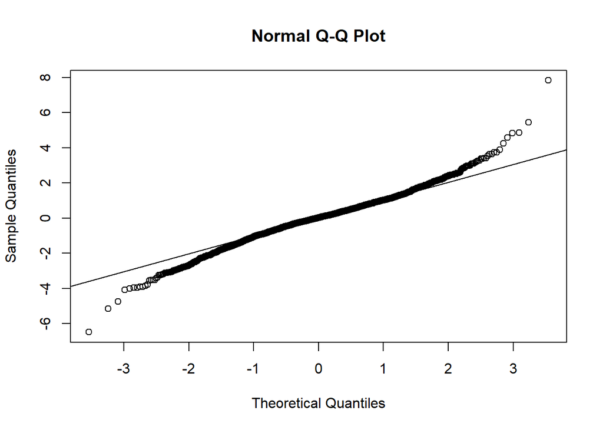

```r
qqnorm(x_normalized); qqline(x_normalized)
```

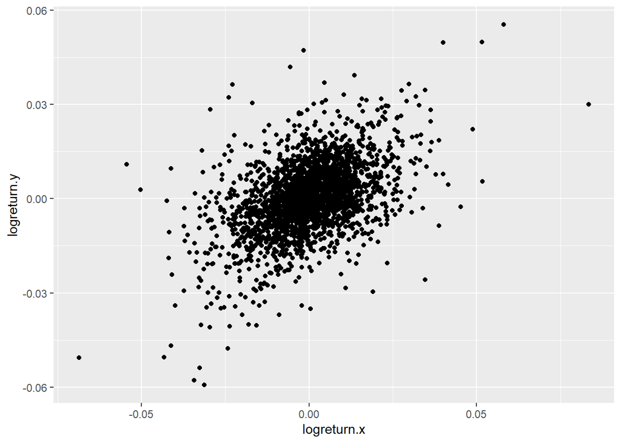

```r
# t-distribution better


#Uppgift 4

both_stocks <- inner_join(Apple, Microsoft, by="Date")

both_stocks %>%
  ggplot(aes(x=logreturn.x, y=logreturn.y)) +
  geom_point()
```

```r
#Positive Correlation goodie goodie


#Uppgift 5

cor(both_stocks$logreturn.x, both_stocks$logreturn.y)
```

```
## [1] 0.4772175
```

```r
#Daily correlation is 0.477 looks good like scatterplot
```